# Manual

N. Frerebeau

2022-06-12

## 0.1 Definitions

The **arkhe** package provides a set of S4 classes for archaeological data matrices. These new classes represent different special types of matrix.

- Integer matrix:
  - `CountMatrix` represents absolute frequency data,
  - `OccurrenceMatrix` represents a co-occurrence matrix,
- Numeric matrix:
  - `CompositionMatrix` represents relative frequency data,
- Logical matrix:
  - `IncidenceMatrix` represents presence/absence data,
  - `StratigraphicMatrix` represents stratigraphic relationships.

*It assumes that you keep your data tidy*: each variable (taxon/type) must be saved in its own column and each observation (assemblage/sample) must be saved in its own row. Note that missing values are not allowed.

The internal structure of S4 classes implemented in **arkhe** is depicted in the UML class diagram in the following figure.

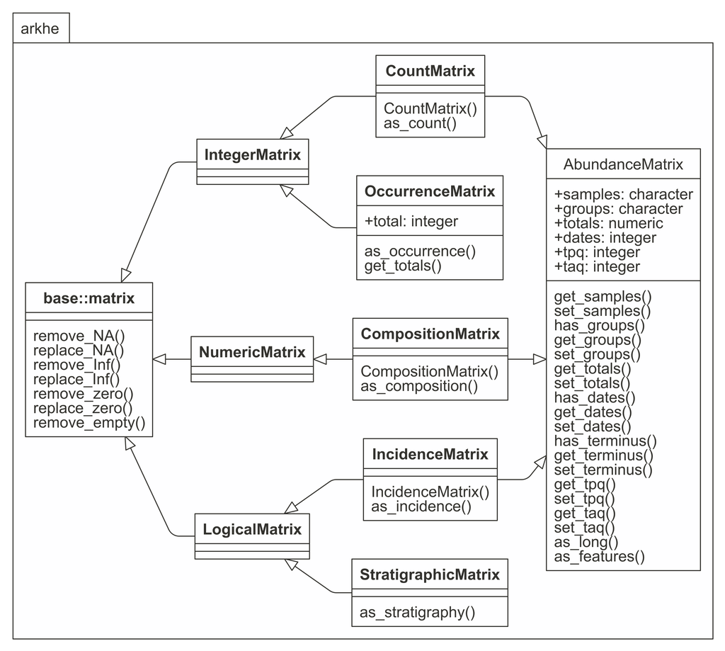

UML class diagram of the S4 classes structure.

### 0.1.1 Numeric matrix

#### 0.1.1.1 Absolute frequency matrix (`CountMatrix`)

We denote the $m \times p$ count matrix by $A = \left[ a_{ij} \right] ~\forall i \in \left[ 1,m \right], j \in \left[ 1,p \right]$ with row and column sums:

$$\begin{align}
a_{i \cdot} = \sum_{j = 1}^{p} a_{ij} &&
a_{\cdot j} = \sum_{i = 1}^{m} a_{ij} &&
a_{\cdot \cdot} = \sum_{i = 1}^{m} \sum_{j = 1}^{p} a_{ij} &&
\forall a_{ij} \in \mathbb{N}
\end{align}$$

#### 0.1.1.2 Relative frequency matrix (`CompositionMatrix`)

A frequency matrix represents relative abundances.

We denote the $m \times p$ frequency matrix by $B = \left[ b_{ij} \right] ~\forall i \in \left[ 1,m \right], j \in \left[ 1,p \right]$ with row and column sums:

$$\begin{align}
b_{i \cdot} = \sum_{j = 1}^{p} b_{ij} = 1 &&
b_{\cdot j} = \sum_{i = 1}^{m} b_{ij} &&
b_{\cdot \cdot} = \sum_{i = 1}^{m} \sum_{j = 1}^{p} b_{ij} &&
\forall b_{ij} \in \left[ 0,1 \right]
\end{align}$$

#### 0.1.1.3 Co-occurrence matrix (`OccurrenceMatrix`)

A co-occurrence matrix is a symmetric matrix with zeros on its main diagonal, which works out how many times each pairs of taxa occur together in at least one sample.

The $p \times p$ co-occurrence matrix $D = \left[ d_{i,j} \right] ~\forall i,j \in \left[ 1,p \right]$ is defined over an $m \times p$ abundance matrix $A = \left[ a_{x,y} \right] ~\forall x \in \left[ 1,m \right], y \in \left[ 1,p \right]$ as:

$$d_{i,j} = \sum_{x = 1}^{m} \bigcap_{y =
i}^{j} a_{xy}$$

with row and column sums:

$$\begin{align}
d_{i \cdot} = \sum_{j \geqslant i}^{p} d_{ij} &&
d_{\cdot j} = \sum_{i \leqslant j}^{p} d_{ij} &&
d_{\cdot \cdot} = \sum_{i = 1}^{p} \sum_{j \geqslant i}^{p} d_{ij}
&&
\forall d_{ij} \in \mathbb{N}
\end{align}$$

### 0.1.2 Logical matrix

#### 0.1.2.1 Incidence matrix (`IncidenceMatrix`)

We denote the $m \times p$ incidence matrix by $C = \left[ c_{ij} \right] ~\forall i \in \left[ 1,m \right], j \in \left[ 1,p \right]$ with row and column sums:

$$\begin{align}
c_{i \cdot} = \sum_{j = 1}^{p} c_{ij} &&
c_{\cdot j} = \sum_{i = 1}^{m} c_{ij} &&
c_{\cdot \cdot} = \sum_{i = 1}^{m} \sum_{j = 1}^{p} c_{ij} &&
\forall c_{ij} \in \lbrace 0,1 \rbrace
\end{align}$$

## 0.2 Usage

```r
## Load packages
library(arkhe)
```

### 0.2.1 Create

These new classes are of simple use, on the same way as the base `matrix`:

```r
set.seed(12345)
### Create a count data matrix
### Data are rounded to zero decimal places, then coerced with as.integer
CountMatrix(data = sample(0:10, 100, TRUE),
            nrow = 10, ncol = 10)
```

```
#> <CountMatrix: 10 x 10>
#>       col1 col2 col3 col4 col5 col6 col7 col8 col9 col10
#> row1     2    6    2    3    9    7    9    3    3     6
#> row2     9    9    8    7    9   10    6    8    9     0
#> row3     7    0    3   10    2    3    6   10    3     2
#> row4     9    7    9    5    2    1    4    0    8     1
#> row5    10    6    6    8    2    2    6    2    1     4
#> row6     7    5    1    4    0    5    9    9    7     9
#> row7     1    0    3    2    9    2    7    6    9     5
#> row8     5    3   10    0    7    6    2    9    0     6
#> row9    10    7    8    0   10    9    4    9    8     8
#> row10    5    9    8    4    8    6   10    6    5     9
```

```r
### Create an incidence (presence/absence) matrix
### Data are coerced to logical as by as.logical
IncidenceMatrix(data = sample(0:1, 100, TRUE),
                nrow = 10, ncol = 10)
```

```
#> <IncidenceMatrix: 10 x 10>
#>        col1  col2  col3  col4  col5  col6  col7  col8  col9 col10
#> row1   TRUE FALSE  TRUE FALSE FALSE FALSE  TRUE FALSE FALSE  TRUE
#> row2   TRUE  TRUE  TRUE FALSE  TRUE FALSE FALSE FALSE FALSE FALSE
#> row3   TRUE  TRUE  TRUE FALSE  TRUE FALSE  TRUE FALSE  TRUE  TRUE
#> row4   TRUE FALSE  TRUE  TRUE FALSE  TRUE FALSE FALSE  TRUE  TRUE
#> row5  FALSE FALSE  TRUE FALSE  TRUE  TRUE FALSE FALSE  TRUE  TRUE
#> row6   TRUE  TRUE  TRUE FALSE  TRUE FALSE FALSE FALSE FALSE  TRUE
#> row7   TRUE FALSE  TRUE FALSE FALSE  TRUE FALSE FALSE  TRUE  TRUE
#> row8  FALSE FALSE  TRUE  TRUE  TRUE FALSE  TRUE  TRUE FALSE FALSE
#> row9  FALSE  TRUE  TRUE  TRUE  TRUE  TRUE FALSE  TRUE FALSE FALSE
#> row10  TRUE FALSE FALSE FALSE FALSE  TRUE FALSE FALSE FALSE FALSE
```

### 0.2.2 Coerce

**arkhe** uses coercing mechanisms (with validation methods) for data type conversions:

```r
### Create a count matrix
A0 <- matrix(data = sample(0:10, 100, TRUE), nrow = 10, ncol = 10)

### Coerce to absolute frequencies
A1 <- as_count(A0)

### Coerce to relative frequencies
B <- as_composition(A1)

### Row sums are internally stored before coercing to a frequency matrix
### (use get_totals() to get these values)
### This allows to restore the source data
A2 <- as_count(B)
all(A1 == A2)
```

```
#> [1] TRUE
```

```r
### Coerce to presence/absence
C <- as_incidence(A1)

### Coerce to a co-occurrence matrix
D <- as_occurrence(A1)
```